# Lab 3

## (2) Splines

An alternative way to model this is to use the spline functions. **Spline** is a smooth function built out of smaller, component functions. The example we are using here is called **B-spline**, which stands for the basis spline functions: essentially, B-splines build up functions that are very wiggly from smaller component functions that are less wiggly. **By taking mixtures of some simple functions, we get the complicated, wiggly function that we use to model the nonlinear relationship**. We will see how to do this in a minute.

```r
precis(d)
```

```
'data.frame': 1215 obs. of 5 variables:
```

|  | mean | sd | 5.5% | 94.5% | histogram |
| --- | --- | --- | --- | --- | --- |
| year | 1408.00 | 350.88 | 867.77 | 1948.23 | ▇▇▇▇▇▇▇▇▇▇▇▇▁ |
| doy | 104.54 | 6.41 | 94.43 | 115.00 | ▁▂▅▇▇▃▁▁ |
| temp | 6.14 | 0.66 | 5.15 | 7.29 | ▁▃▅▇▃▂▁▁ |
| temp_upper | 7.19 | 0.99 | 5.90 | 8.90 | ▁▂▅▇▇▅▂▂▁▁▁▁▁▁▁ |
| temp_lower | 5.10 | 0.85 | 3.79 | 6.37 | ▁▁▁▁▁▁▁▃▅▇▃▂▁▁▁ |

### How does spline functions work?

#### Knots and Basis functions

The first step in modeling splines is to choose the range in which you want to model the wiggly function and the number of **knots** in that range. Essentially, knots determine how many basis functions you have in this range. **If you have $K$ knots, you split the range into (usually identical) $(K-1)$ parts, and each knot will correspond to a few basis function. Given the range and the number of knots, the number of basis functions is known and all the basis functions will be known and computable. For example, if we have 5 knots in the range $[0,1]$ for a linear spline model, for $\forall x \in [0,1]$, the Basis functions $B_1(x), ..., B_5(x)$ can be evaluated at any point.

An important observation you may get from this model is that if you are closer to a knot, you tend to get higher values in the Basis functions related to that knot, on the other hand if you move away from it, those Basis functions tends to shrink to zero. This corresponds to the intuition that **we use spline models to do local approximations**. You can think of this in the way that the Basis function that are close to your data has larger values, and therefore they have a heavier influence in determining the regression function near this point. As for the basis functions away from the point, a lot of them are zero so they wouldn’t even affect the estimation result.

Finally, we can determine how `smooth’ these basis function can be by setting the **polynomial degree**. Essentially, if the polynomial degree is $k$, $(k+1)$ basis functions will collectively determine a given point (barring some special cases in the boundary). Higher orders lead to basis functions that are more ‘smooth’.

#### Weights

The next step in building our spline functions is to determine the weights for each of the basis functions. As our expected outcome can be expressed as a linear combination of the basis functions, we can re-express the mean function $\mu(x)$ as follows (similar to what we did before in the polynomial regression example, we introduce the parameter $\alpha$ as an intercept term):

$$\mu(x) = \alpha + \sum_{k=1}^Kw_k B_k(x)$$

Apparently, we do not have data for every $x$ on this range. To fit this model, we evaluate the Basis functions $\{B_k(x)\}_{k=1}^K$ for the each of the predictor variables $x_1, ..., x_n$. We define $B_{i,k} := B_k(x_i)$. Thus we have

$$\mu_i = \alpha + \sum_{k=1}^Kw_k B_{i,k} = \alpha + \mathbf{B}_{n \times K} \boldsymbol{w}_{K \times 1}$$

(On a side note, we can rephrase this in the matrix form and put all the $B$’s in a matrix. The numbers of rows will be the number of observations/years, and the columns will be the number of basis functions. The weights for the $K$ basis functions are stored into the vector.)

You’ll discover that the equation that we have above is very similar to the regression function we had in the polynomial regression model. The only difference is that instead of taking the squares or cubes of $x_i$, we transform them through the basis functions to get $B_{i1}, ..., B_{ik}$ (these are called `synthetic variables’ in the textbook).

### Fitting the model

At this point, we see that this model is essentially a linear regression model, if you treat each column of the $\mathbf{B}$ matrix as a separate predictor variable. We let $T_i$ be the temperature observed

$$\begin{aligned}
T_{i} & \sim \operatorname{Normal}\left(\mu_{i}, \sigma\right) \\
\mu_{i} &=\alpha+\sum_{k=1}^{K} w_{k} B_{k, i} \\
\alpha & \sim \operatorname{Normal}(6,10) \\
w_{j} & \sim \operatorname{Normal}(0,1) \\
\sigma & \sim \operatorname{Exponential}(1)
\end{aligned}$$

We see that this model is very similar to the polynomial regression model.

```r
length(knot_list)
```

```
[1] 15
```

```r
library(splines)
B <- bs(d2$year,
    knots=knot_list[-c(1,num_knots)] ,
    degree=3 , intercept=TRUE )
dim(B) # check dimensions of this matrix
```

```
[1] 1124   17
```

```r
plot( NULL , xlim=range(d2$year) , ylim=c(0,1) , xlab="year" , ylab="basis value")
for ( i in 1:ncol(B) ) lines( d2$year , B[,i] )
```

[output not shown]

Finally, we fit this model using R, given that we have all the pieces.

```r
m4.7 <- quap(
    alist(
        T ~ dnorm( mu , sigma ) ,
        mu <- a + B %*% w , # matrix expressions of B and w
        a ~ dnorm(6,10),
        w ~ dnorm(0,1),
        sigma ~ dexp(1)
    ),
    data=list( T=d2$temp , B=B ) ,
    start=list( w=rep( 0 , ncol(B)))) # we havent defined w before, so we let quap() know that w is a vector with 17 elements (need to be the same as the column of the B matrix).
```

### The results

```r
post <- extract.samples(m4.7)
w <- apply( post$w , 2 , mean )
plot( NULL , xlim=range(d2$year) , ylim=c(-2,2) ,
    xlab="year" , ylab="basis * weight" )
for ( i in 1:ncol(B) ) lines( d2$year , w[i]*B[,i] )
```

[output not shown]

And finally we plot the $97\%$ posterior credible interval for the expected temperature, given the temperature observed:

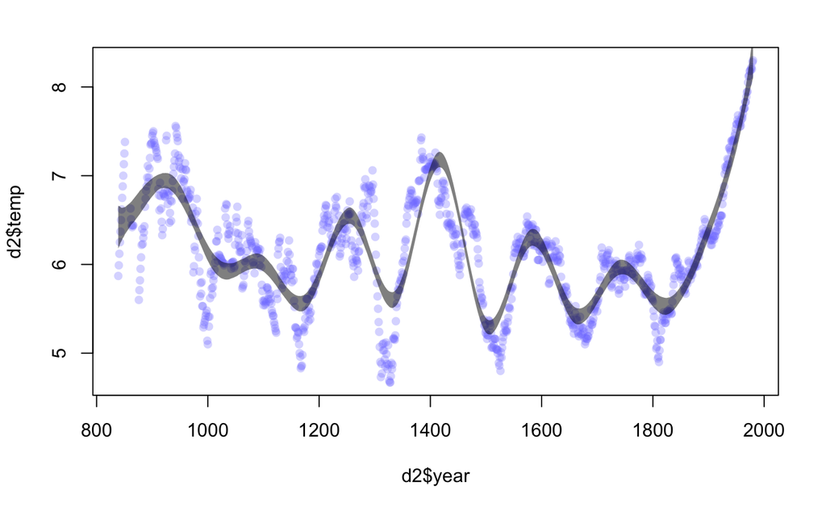

```r
mu <- link( m4.7 )
mu_PI <- apply(mu,2,PI,0.97)
plot( d2$year , d2$temp , col=col.alpha(rangi2,0.3) , pch=16 )
shade( mu_PI , d2$year , col=col.alpha("black",0.5) )
```

### Some final comments

- We see that the expected outcome given by the spline models is very ‘wiggly’ and it is pretty close to the actual data. You can even customize your results by tweaking the number of knots and polynomial orders in the model.
- Again, high polynomial order and more knots may lead to more `flexible’ results but that’s not necessarily a good thing, as you may risk overfitting the data and end up learning the noise – more of this in future lectures.

# Summary

- We start our model with a Gaussian distribution with the same mean for each observation: $\mu_i = \mu$
- Given a predictor variable $X_i$, we can build a **linear relationship** with the predicted mean and the predictor: $\mu_i =\alpha + \beta x_i$
- We can add more flexibility to the previous model by adding **polynomial order terms**: $\mu_i =\alpha + \beta_1 x_i + \beta_2 x_i^2$
- Finally, we can use **splines** to model really wiggly data: $\mu_i = \alpha + \sum_{k=1}^Kw_k B_{i,k}(x_i)$